# R35-Naive Bayes Classification

# Source

- Blogger’s instruction with R
  - https://www.r-bloggers.com/naive-bayes-classification-in-r-part-1/
  - https://www.r-bloggers.com/naive-bayes-classification-in-r-part-2/
- Well-known cases
  - Breast cancer data sourced from Matjaz Zwitter and Milan Soklic from the Institute of Oncology, University Medical Center in Ljubljana, Slovenia (formerly Yugoslavia)

# 機率基礎 － 獨立與互斥

# Naive Bayes Equation

- Posteriori Probability比較像是我現在知道某個事情的特徵，但我不知道他會不會怎樣，而Likelihood比較像是從已知資料中推機率，例如已經有五個會購買的人，有多少人是女性。所以等號右邊為已知的機率，左邊為未知的機率。整體概念類似
- $posterior=prior×likelihood/evidence$
- $P(C | X) = P(C) \times P(X | C) / P(X)$
  - $P(C | X): postriori Probability$
  - $P(C): class prior probability$
  - $P(X | C): Likelihood$
  - $P(C): predictor probability$
- 以下為推導方法：
  - $P(X \bigcap C) = P(X) \times P(C | X)$
  - $P(C | X) = P(X \bigcap C) / P(X) \because P(X \bigcap C) = P(C) \times P(X | C)$
  - $P(C | X) = P(C) \times P(X | C) / P(X)$
  - $P(X) \times P(C | X) = P(C) \times P(X | C)$
- 如果轉成預測的文字說明的話如以下：
  - $P(outcome | evidence) = P(outcome) \times P(evidence | outcome) / P(evidence)$
- 為何會說是Naive是因為我們假設每個屬性間是相互獨立的，但事實上可能不是獨立的。

# Calculating Naive Classier by hand

- 考慮以下的例子，根據以下資料，假設你打算判斷新進樣本X「女性、年齡介於31~40之間、上班族、月收入中等者」，會不會辦信用卡(http://mropengate.blogspot.tw/2015/06/ai-ch14-3-naive-bayes-classifier.html)。

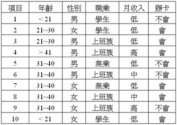